# Students Performance Data Analysis

Hasan Ali ÖZKAN

13/10/2021

### This data set consists of the marks secured by the students in various subjects(1000 observations of 8 columns).

##### Let’s get the data from the **‘.csv’** file and look it’s first 6 rows.

```r
student_performance <- read.csv("StudentsPerformance.csv",header = TRUE,sep = ',')
head(student_performance)
```

```
##   gender ethnicity parental.level.of.edu        lunch test.prep.course
## 1 female   group B     bachelor's degree     standard             none
## 2 female   group C          some college     standard        completed
## 3 female   group B       master's degree     standard             none
## 4   male   group A    associate's degree free/reduced             none
## 5   male   group C          some college     standard             none
## 6 female   group B    associate's degree     standard             none
##   math.score reading.score writing.score
## 1         72            72            74
## 2         69            90            88
## 3         90            95            93
## 4         47            57            44
## 5         76            78            75
## 6         71            83            78
```

##### *OOOPS!!?* Our output is not user friendly. Let’s try something to tidy our output.

```r
library(knitr)
kable(head(student_performance),format="markdown")
```

| gender | ethnicity | parental.level.of.edu | lunch | test.prep.course | math.score | reading.score | writing.score |
| --- | --- | --- | --- | --- | --- | --- | --- |
| female | group B | bachelor’s degree | standard | none | 72 | 72 | 74 |
| female | group C | some college | standard | completed | 69 | 90 | 88 |
| female | group B | master’s degree | standard | none | 90 | 95 | 93 |
| male | group A | associate’s degree | free/reduced | none | 47 | 57 | 44 |
| male | group C | some college | standard | none | 76 | 78 | 75 |
| female | group B | associate’s degree | standard | none | 71 | 83 | 78 |

##### Let’s deep dive into our variables to understand their meaning by calling *summary()* function.

```r
summary(student_performance)
```

```
##     gender           ethnicity         parental.level.of.edu    lunch
##  Length:1000        Length:1000        Length:1000           Length:1000
##  Class :character   Class :character   Class :character      Class :character
##  Mode  :character   Mode  :character   Mode  :character      Mode  :character
##
##
##
##  test.prep.course     math.score     reading.score    writing.score
##  Length:1000        Min.   :  0.00   Min.   : 17.00   Min.   : 10.00
##  Class :character   1st Qu.: 57.00   1st Qu.: 59.00   1st Qu.: 57.75
##  Mode  :character   Median : 66.00   Median : 70.00   Median : 69.00
##                     Mean   : 66.09   Mean   : 69.17   Mean   : 68.05
##                     3rd Qu.: 77.00   3rd Qu.: 79.00   3rd Qu.: 79.00
##                     Max.   :100.00   Max.   :100.00   Max.   :100.00
```

##### *OOOPS!!* As you see above there are some mistakes classes of our variables. Let’s fix them.For example **gender** and **ethnicity** are categorical variable so we should redefine those as a factor. Lets do that:)

```r
student_performance$gender <- as.factor(student_performance$gender)
student_performance$ethnicity <- as.factor(student_performance$ethnicity)
```

##### If we recall *summary()* function. We can see mistakes have gone.

```r
summary(student_performance)
```

```
##     gender      ethnicity   parental.level.of.edu    lunch
##  female:518   group A: 89   Length:1000           Length:1000
##  male  :482   group B:190   Class :character      Class :character
##               group C:319   Mode  :character      Mode  :character
##               group D:262
##               group E:140
##
##  test.prep.course     math.score     reading.score    writing.score
##  Length:1000        Min.   :  0.00   Min.   : 17.00   Min.   : 10.00
##  Class :character   1st Qu.: 57.00   1st Qu.: 59.00   1st Qu.: 57.75
##  Mode  :character   Median : 66.00   Median : 70.00   Median : 69.00
##                     Mean   : 66.09   Mean   : 69.17   Mean   : 68.05
##                     3rd Qu.: 77.00   3rd Qu.: 79.00   3rd Qu.: 79.00
##                     Max.   :100.00   Max.   :100.00   Max.   :100.00
```

##### Let’s add another variable in our data to keep an average of all scores for each student by using *mutate()* function.

```r
student_performance <- mutate(student_performance,
       avg.score= (math.score+reading.score+writing.score)/3)
```

```r
kable(head(student_performance),format="markdown")
```

| gender | ethnicity | parental.level.of.edu | lunch | test.prep.course | math.score | reading.score | writing.score | avg.score |
| --- | --- | --- | --- | --- | --- | --- | --- | --- |
| female | group B | bachelor’s degree | standard | none | 72 | 72 | 74 | 72.66667 |
| female | group C | some college | standard | completed | 69 | 90 | 88 | 82.33333 |
| female | group B | master’s degree | standard | none | 90 | 95 | 93 | 92.66667 |
| male | group A | associate’s degree | free/reduced | none | 47 | 57 | 44 | 49.33333 |
| male | group C | some college | standard | none | 76 | 78 | 75 | 76.33333 |
| female | group B | associate’s degree | standard | none | 71 | 83 | 78 | 77.33333 |

##### As you see above **avg.score** variable has been added.Let’s choose the *TOP-10* students in our data by using their average scores.

```r
top10_students <-head(arrange(student_performance,desc(avg.score)),10)
kable(select(top10_students,gender:parental.level.of.edu,test.prep.course,avg.score),format="markdown")
```

| gender | ethnicity | parental.level.of.edu | test.prep.course | avg.score |
| --- | --- | --- | --- | --- |
| female | group E | bachelor’s degree | none | 100.00000 |
| male | group E | bachelor’s degree | completed | 100.00000 |
| female | group E | associate’s degree | none | 100.00000 |
| female | group E | bachelor’s degree | completed | 99.66667 |
| female | group D | some high school | completed | 99.00000 |
| female | group D | some college | none | 99.00000 |
| female | group C | bachelor’s degree | completed | 98.66667 |
| male | group D | some college | completed | 98.66667 |
| male | group E | associate’s degree | completed | 97.66667 |
| female | group E | master’s degree | completed | 97.66667 |

##### As you see above there are some students who are in the *TOP-10* but they are not complete test-preparation-course.Let’s try to filter them then select the *TOP-10* student.

```r
prep_course_completed_students <- filter(student_performance,test.prep.course=="completed")
prep_course_completed_students_top10 <- head(arrange(prep_course_completed_students,desc(avg.score)),10)
kable(select(prep_course_completed_students_top10,gender:parental.level.of.edu,test.prep.course,avg.score),format="markdown")
```

| gender | ethnicity | parental.level.of.edu | test.prep.course | avg.score |
| --- | --- | --- | --- | --- |
| male | group E | bachelor’s degree | completed | 100.00000 |
| female | group E | bachelor’s degree | completed | 99.66667 |
| female | group D | some high school | completed | 99.00000 |
| female | group C | bachelor’s degree | completed | 98.66667 |
| male | group D | some college | completed | 98.66667 |
| male | group E | associate’s degree | completed | 97.66667 |
| female | group E | master’s degree | completed | 97.66667 |
| female | group D | bachelor’s degree | completed | 97.66667 |
| female | group E | bachelor’s degree | completed | 97.33333 |
| female | group C | bachelor’s degree | completed | 97.00000 |

##### Finally, let’s make up a threshold value to pass the class.Let’s assume that another criterion is to pass the preparatory course test and call the threshold value 60 and see how many of the students passed the class :)

```r
prep_course_completed_students <- filter(student_performance,test.prep.course=="completed")
passed_students <- filter(prep_course_completed_students,avg.score>=60)
number_of_passed_students <- count(passed_students)
print(paste("The number of students who passed the class is ",number_of_passed_students))
```

```
## [1] "The number of students who passed the class is  298"
```

##### *Wow that’s great!!!* Almost one-third of the students passed the class:)

##### Finally, let’s visualize our data with some meaningful and clear graphics.

##### Just I want to look for is there any correlation between *math.score* and other scores.Let’s create a scatter plot to understand that.

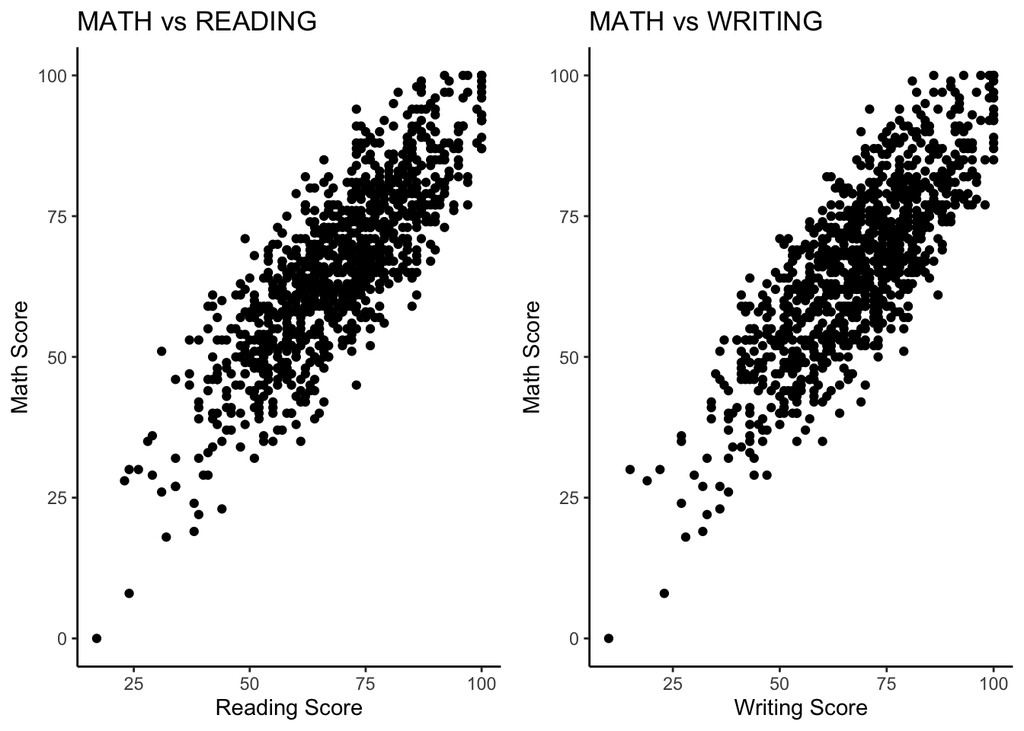

```r
math_reading <- ggplot(student_performance)+
  geom_point(mapping = aes(x=reading.score,y=math.score))+
  labs(title="MATH vs READING",
       y="Math Score",x="Reading Score")+theme_classic()


math_writing <- ggplot(student_performance)+
  geom_point(mapping = aes(x=writing.score,y=math.score))+
  labs(title="MATH vs WRITING",
       y="Math Score",x="Writing Score")+theme_classic()


figure <- ggpubr::ggarrange(math_reading,math_writing,ncol=2,nrow=1)
figure
```

##### As you see above there is a positive correlation between **math.scores** and other scores.

##### Let’s look is **ethnicity** important to be successful?

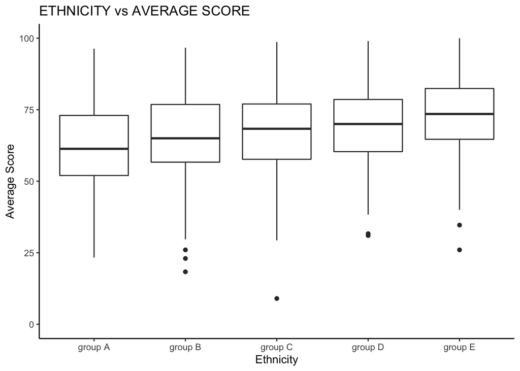

```r
ggplot(student_performance) +
  geom_boxplot(mapping = aes(x = ethnicity, y =avg.score))+
  coord_cartesian(ylim = c(0,100))+
  labs(title="ETHNICITY vs AVERAGE SCORE",
       x="Ethnicity",y="Average Score")+
   theme_classic()
```